# R Notebook

```r
library(DataComputing)
library(dplyr)
library(ggmap)
library(ggrepel)
library(tidyverse)
#Importing two different data sources.
airport_data <- read.csv("196400287_T_MASTER_CORD.csv")
routes_data <- read.csv("routes.csv")
```

### Inspecting Imported Data Sources

```r
str(airport_data)
```

```
'data.frame':   18094 obs. of  29 variables:
 $ AIRPORT_SEQ_ID                : int  1000101 1000301 1000401 1000501 1000601 1000701 1000801 1000901 1001001 1001002 ...
 $ AIRPORT_ID                    : int  10001 10003 10004 10005 10006 10007 10008 10009 10010 10010 ...
 $ AIRPORT                       : Factor w/ 6559 levels "01A","03A","04A",..: 1 2 3 4 5 6 7 8 9 9 ...
 $ DISPLAY_AIRPORT_NAME          : Factor w/ 8068 levels "17 de Setembro",..: 72 689 4201 4232 3841 3850 2220 460 1642 1642 ...
 $ DISPLAY_AIRPORT_CITY_NAME_FULL: Factor w/ 6297 levels "108 Mile Ranch, Canada",..: 40 2124 3169 3197 2878 2882 1708 2367 2405 2405 ...
 $ AIRPORT_WAC                   : int  1 1 1 1 1 1 1 1 22 22 ...
 $ AIRPORT_COUNTRY_NAME          : Factor w/ 256 levels "Afghanistan",..: 242 242 242 242 242 242 242 242 242 242 ...
 $ AIRPORT_COUNTRY_CODE_ISO      : Factor w/ 239 levels "","AE","AF","AG",..: 222 222 222 222 222 222 222 222 222 222 ...
 $ AIRPORT_STATE_NAME            : Factor w/ 68 levels "","Alabama","Alaska",..: 3 3 3 3 3 3 3 3 38 38 ...
 $ AIRPORT_STATE_CODE            : Factor w/ 68 levels "","AB","AK","AL",..: 3 3 3 3 3 3 3 3 44 44 ...
 $ AIRPORT_STATE_FIPS            : int  2 2 2 2 2 2 2 2 36 36 ...
 $ CITY_MARKET_ID                : int  30001 30003 30004 30005 30006 30007 30008 30009 30010 30010 ...
 $ DISPLAY_CITY_MARKET_NAME_FULL : Factor w/ 6190 levels "108 Mile Ranch, Canada",..: 40 2082 3111 3139 2823 2827 1679 2323 2359 2359 ...
 $ CITY_MARKET_WAC               : int  1 1 1 1 1 1 1 1 22 22 ...
 $ LAT_DEGREES                   : int  58 65 68 67 57 55 59 59 42 42 ...
 $ LAT_HEMISPHERE                : Factor w/ 3 levels "","N","S": 2 2 2 2 2 2 2 2 2 2 ...
 $ LAT_MINUTES                   : int  6 32 5 34 44 33 9 21 17 17 ...
 $ LAT_SECONDS                   : int  34 53 0 12 43 17 25 46 20 29 ...
 $ LATITUDE                      : num  58.1 65.5 68.1 67.6 57.7 ...
 $ LON_DEGREES                   : int  152 161 163 148 152 133 151 153 73 73 ...
 $ LON_HEMISPHERE                : Factor w/ 3 levels "","E","W": 3 3 3 3 3 3 3 3 3 3 ...
 $ LON_MINUTES                   : int  54 4 10 11 52 6 49 25 42 42 ...
 $ LON_SECONDS                   : int  24 18 0 2 58 6 45 50 37 37 ...
 $ LONGITUDE                     : num  -153 -161 -163 -148 -153 ...
 $ AIRPORT_START_DATE            : Factor w/ 507 levels "1950-01-01","1950-02-01",..: 378 378 378 379 381 386 387 387 395 416 ...
 $ AIRPORT_THRU_DATE             : Factor w/ 347 levels "","1950-01-31",..: 1 1 1 1 1 1 1 1 277 1 ...
 $ AIRPORT_IS_CLOSED             : int  0 0 0 0 0 0 0 0 0 0 ...
 $ AIRPORT_IS_LATEST             : int  1 1 1 1 1 1 1 1 0 1 ...
 $ X                             : logi  NA NA NA NA NA NA ...
```

```r
head(airport_data)
```

|  | AIRPORT_SEQ_ID | AIRPORT_ID | AIRPORT | DISPLAY_AIRPORT_NAME | DISPLAY_AIRPORT_CITY_NAME_FULL | AIRPORT_WAC | AIRPORT_COUNTRY_NAME | AIRPORT_COUNTRY_CODE_ISO | AIRPORT_STATE_NAME | AIRPORT_STATE_CODE | AIRPORT_STATE_FIPS | CITY_MARKET_ID | DISPLAY_CITY_MARKET_NAME_FULL | CITY_MARKET_WAC | LAT_DEGREES | LAT_HEMISPHERE | LAT_MINUTES | LAT_SECONDS | LATITUDE | LON_DEGREES | LON_HEMISPHERE | LON_MINUTES | LON_SECONDS | LONGITUDE | AIRPORT_START_DATE | AIRPORT_THRU_DATE | AIRPORT_IS_CLOSED | AIRPORT_IS_LATEST | X |
| --- | --- | --- | --- | --- | --- | --- | --- | --- | --- | --- | --- | --- | --- | --- | --- | --- | --- | --- | --- | --- | --- | --- | --- | --- | --- | --- | --- | --- | --- |
| 1 | 1000101 | 10001 | 01A | Afognak Lake Airport | Afognak Lake, AK | 1 | United States | US | Alaska | AK | 2 | 30001 | Afognak Lake, AK | 1 | 58 | N | 6 | 34 | 58.10944 | 152 | W | 54 | 24 | -152.9067 | 2007-07-01 |  | 0 | 1 | NA |
| 2 | 1000301 | 10003 | 03A | Bear Creek Mining Strip | Granite Mountain, AK | 1 | United States | US | Alaska | AK | 2 | 30003 | Granite Mountain, AK | 1 | 65 | N | 32 | 53 | 65.54806 | 161 | W | 4 | 18 | -161.0717 | 2007-07-01 |  | 0 | 1 | NA |
| 3 | 1000401 | 10004 | 04A | Lik Mining Camp | Lik, AK | 1 | United States | US | Alaska | AK | 2 | 30004 | Lik, AK | 1 | 68 | N | 5 | 0 | 68.08333 | 163 | W | 10 | 0 | -163.1667 | 2007-07-01 |  | 0 | 1 | NA |
| 4 | 1000501 | 10005 | 05A | Little Squaw Airport | Little Squaw, AK | 1 | United States | US | Alaska | AK | 2 | 30005 | Little Squaw, AK | 1 | 67 | N | 34 | 12 | 67.57000 | 148 | W | 11 | 2 | -148.1839 | 2007-08-01 |  | 0 | 1 | NA |
| 5 | 1000601 | 10006 | 06A | Kizhuyak Bay | Kizhuyak, AK | 1 | United States | US | Alaska | AK | 2 | 30006 | Kizhuyak, AK | 1 | 57 | N | 44 | 43 | 57.74528 | 152 | W | 52 | 58 | -152.8828 | 2007-10-01 |  | 0 | 1 | NA |
| 6 | 1000701 | 10007 | 07A | Klawock Seaplane Base | Klawock, AK | 1 | United States | US | Alaska | AK | 2 | 30007 | Klawock, AK | 1 | 55 | N | 33 | 17 | 55.55472 | 133 | W | 6 | 6 | -133.1017 | 2008-04-01 |  | 0 | 1 | NA |

```r
str(routes_data)
```

```
'data.frame':   67663 obs. of  9 variables:
 $ airline               : Factor w/ 568 levels "2B","2G","2I",..: 1 1 1 1 1 1 1 1 1 1 ...
 $ airline.ID            : Factor w/ 548 levels "\\N","10","1006",..: 382 382 382 382 382 382 382 382 382 382 ...
 $ source.airport        : Factor w/ 3409 levels "AAE","AAL","AAN",..: 50 152 152 472 472 699 699 699 699 771 ...
 $ source.airport.id     : Factor w/ 3321 levels "\\N","1","10",..: 1116 1117 1117 1119 1119 1755 1755 1755 1755 2517 ...
 $ destination.apirport  : Factor w/ 3418 levels "AAE","AAL","AAN",..: 1557 1557 1901 1557 2154 1557 1979 2785 3001 1403 ...
 $ destination.airport.id: Factor w/ 3327 levels "\\N","1","10",..: 1138 1138 1115 1138 1792 1138 2868 1 2521 1106 ...
 $ codeshare             : Factor w/ 2 levels "","Y": 1 1 1 1 1 1 1 1 1 1 ...
 $ stops                 : int  0 0 0 0 0 0 0 0 0 0 ...
 $ equipment             : Factor w/ 3946 levels ""," 73W 733 73C",..: 2919 2919 2919 2919 2919 2919 2919 2919 2919 2919 ...
```

```r
head(routes_data)
```

|  | airline | airline.ID | source.airport | source.airport.id | destination.apirport | destination.airport.id | codeshare | stops | equipment |
| --- | --- | --- | --- | --- | --- | --- | --- | --- | --- |
| 1 | 2B | 410 | AER | 2965 | KZN | 2990 |  | 0 | CR2 |
| 2 | 2B | 410 | ASF | 2966 | KZN | 2990 |  | 0 | CR2 |
| 3 | 2B | 410 | ASF | 2966 | MRV | 2962 |  | 0 | CR2 |
| 4 | 2B | 410 | CEK | 2968 | KZN | 2990 |  | 0 | CR2 |
| 5 | 2B | 410 | CEK | 2968 | OVB | 4078 |  | 0 | CR2 |
| 6 | 2B | 410 | DME | 4029 | KZN | 2990 |  | 0 | CR2 |

### General Data Wrangling

```r
airport_data <-
  airport_data%>%
  rename(Airport_code = AIRPORT)
```

```r
airports <-
  airport_data%>%
  distinct(Airport_code, .keep_all = TRUE)
```

### Creating leaflet to show multiple airports on worldmap

```r
leaflet(airports)%>%
  addTiles()%>%
  addCircleMarkers(radius = 2,label = ~DISPLAY_AIRPORT_NAME)
```

```
Assuming "LONGITUDE" and "LATITUDE" are longitude and latitude, respectively
Data contains 1 rows with either missing or invalid lat/lon values and will be ignored
```

[interactive chart not shown]

```r
NA
```

### Join Operation for joining the two Data Sets by the column source.airport

```r
JointTable <-
  routes_data %>%
  left_join(airports %>% select(Airport_code,LATITUDE,LONGITUDE), by = c("source.airport" = "Airport_code"))
```

```r
JointTable <-
  JointTable%>%
  rename(source_latitude = LATITUDE,
         source_longitude = LONGITUDE)
```

### Join Operation for joining the two Data Sets by the column destination.apirport

```r
JointTable <-
  JointTable %>%
  left_join(airports %>% select(Airport_code,LATITUDE,LONGITUDE), by = c("destination.apirport" = "Airport_code"))
```

```
Column `destination.apirport`/`Airport_code` joining factors with different levels, coercing to character vector
```

```r
JointTable <-
  JointTable%>%
  rename(destination_latitude = LATITUDE,
         destination_longitude = LONGITUDE)
```

### Inspecting the JointTable

```r
str(JointTable)
```

```
'data.frame':   67663 obs. of  13 variables:
 $ airline               : Factor w/ 568 levels "2B","2G","2I",..: 1 1 1 1 1 1 1 1 1 1 ...
 $ airline.ID            : Factor w/ 548 levels "\\N","10","1006",..: 382 382 382 382 382 382 382 382 382 382 ...
 $ source.airport        : chr  "AER" "ASF" "ASF" "CEK" ...
 $ source.airport.id     : Factor w/ 3321 levels "\\N","1","10",..: 1116 1117 1117 1119 1119 1755 1755 1755 1755 2517 ...
 $ destination.apirport  : chr  "KZN" "KZN" "MRV" "KZN" ...
 $ destination.airport.id: Factor w/ 3327 levels "\\N","1","10",..: 1138 1138 1115 1138 1792 1138 2868 1 2521 1106 ...
 $ codeshare             : Factor w/ 2 levels "","Y": 1 1 1 1 1 1 1 1 1 1 ...
 $ stops                 : int  0 0 0 0 0 0 0 0 0 0 ...
 $ equipment             : Factor w/ 3946 levels ""," 73W 733 73C",..: 2919 2919 2919 2919 2919 2919 2919 2919 2919 2919 ...
 $ source_latitude       : num  43.5 46.3 46.3 55.3 55.3 ...
 $ source_longitude      : num  39.9 48 48 61.5 61.5 ...
 $ destination_latitude  : num  55.6 55.6 44.2 55.6 55 ...
 $ destination_longitude : num  49.3 49.3 43.1 49.3 82.7 ...
```

### Removing the unnecessary columns from JointTable

```r
JointTable <-
  JointTable %>%
  select(airline, source.airport, destination.apirport, equipment, source_latitude, source_longitude, destination_latitude, destination_longitude)
```

### Creating a user - defined function

```r
earth.dist <- function (long1, lat1, long2, lat2)
{
rad <- pi/180
a1 <- lat1 * rad
a2 <- long1 * rad
b1 <- lat2 * rad
b2 <- long2 * rad
dlon <- b2 - a2
dlat <- b1 - a1
a <- (sin(dlat/2))^2 + cos(a1) * cos(b1) * (sin(dlon/2))^2
c <- 2 * atan2(sqrt(a), sqrt(1 - a))
R <- 6378.145
d <- R * c
return(d)
}
```

### Finding the distance between two coordinates

```r
JointTable<-
  JointTable%>%
  mutate(distance = earth.dist(source_longitude,source_latitude,destination_longitude,destination_latitude))
```

### Grouping the distance in short, edium or long with the use of Control Flow (if-else statement)

```r
JointTable <-
  JointTable%>%
  mutate(Distance_class = ifelse(distance <= 3000, "short", ifelse(distance >3000 & distance <= 9000, "Medium", "Long")))
```

### Making a table for all the long routes with the use of reduction/transformation function

```r
LongTable <-
  JointTable%>%
  filter(Distance_class == "Long")%>%
  group_by(equipment)%>%
  summarise(count = n())%>%
  arrange(desc(count))%>%
  head(10)
```

### Plotting a Graph to show which aircraft model (equipment) is most common for long flights

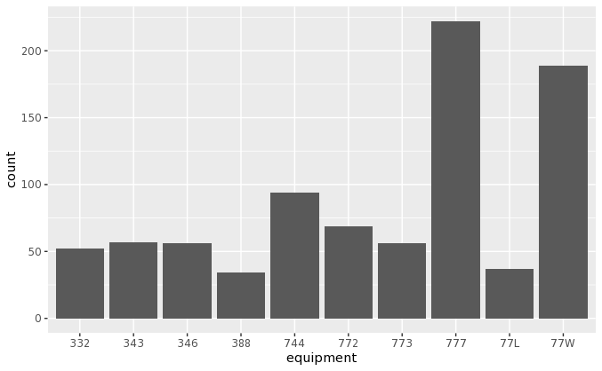

```r
ggplot(data=LongTable,aes(x=equipment,y=count ))+geom_bar(stat='identity',position='stack', width=.9)
```

The above graph tells us that 777 is the most used aircraft model(equipment) for long flights.

```r
routes_777 <-
  JointTable%>%
  filter(Distance_class == "Long", equipment == "777")
```

### Plotting a map to show routes of long flights with the help of multiple different geoms and mutiple aesthetics

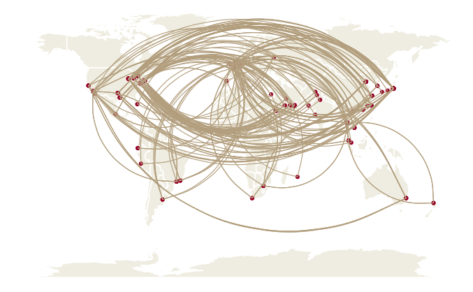

```r
worldmap <- borders("world", colour = "#FFFFFF", fill = "#efede1")
  ggplot() + worldmap +
    geom_point(data = routes_777, aes(x = source_longitude, y = source_latitude), col = "#970027") +
    geom_curve(data = routes_777, aes(x = source_longitude, y = source_latitude, xend = destination_longitude, yend = destination_latitude),
               col = "#b29e7d", size = .4) +
    theme_void()
```

### Making a table for all the medium routes with the use of reduction/transformation function

```r
MediumTable <-
  JointTable%>%
  filter(Distance_class == "Medium")%>%
  group_by(equipment)%>%
  summarise(count = n())%>%
  arrange(desc(count))%>%
  head(10)
```

### Plotting a Graph to show which aircraft model (equipment) is most common for medium flights

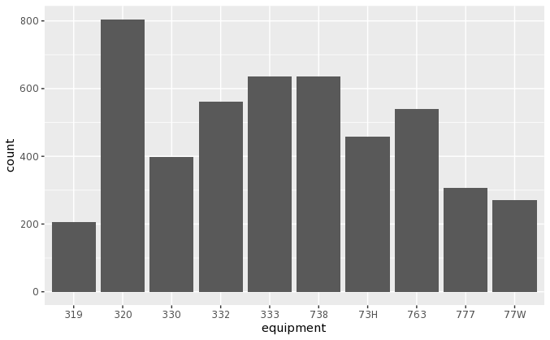

```r
ggplot(data=MediumTable,aes(x=equipment,y=count ))+geom_bar(stat='identity',position='stack', width=.9)
```

The above graph tells us that 320 is the most used aircraft model(equipment) for medium flights.

```r
routes_320 <-
  JointTable%>%
  filter(Distance_class == "Medium", equipment == "320")
```

### Plotting a map to show routes of medium flights with the help of multiple different geoms and mutiple aesthetics

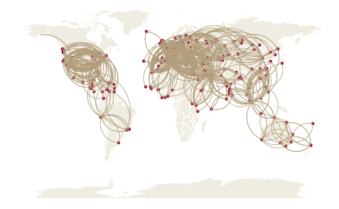

```r
worldmap <- borders("world", colour = "#FFFFFF", fill = "#efede1")
  ggplot() + worldmap +
    geom_point(data = routes_320, aes(x = source_longitude, y = source_latitude), col = "#970027") +
    geom_curve(data = routes_320, aes(x = source_longitude, y = source_latitude, xend = destination_longitude, yend = destination_latitude),
               col = "#b29e7d", size = .4) +
    theme_void()
```

### Making a table for all the short routes with the use of reduction/transformation function

```r
ShortTable <-
  JointTable%>%
  filter(Distance_class == "short")%>%
  group_by(equipment)%>%
  summarise(count = n())%>%
  arrange(desc(count))%>%
  head(10)
```

### Plotting a Graph to show which aircraft model (equipment) is most common for short flights

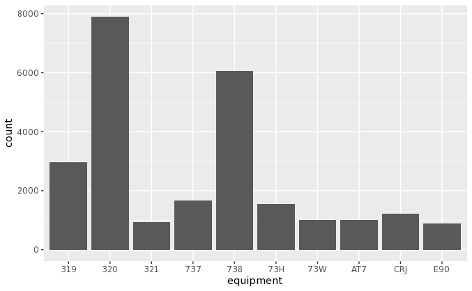

```r
ggplot(data=ShortTable,aes(x=equipment,y=count ))+geom_bar(stat='identity',position='stack', width=.9)
```

The above graph tells us that 320 is the most used aircraft model(equipment) for short flights.

```r
routes_320_short <-
  JointTable%>%
  filter(Distance_class == "short", equipment == "320")
```

### Plotting a map to show routes of short flights with the help of multiple different geoms and mutiple aesthetics

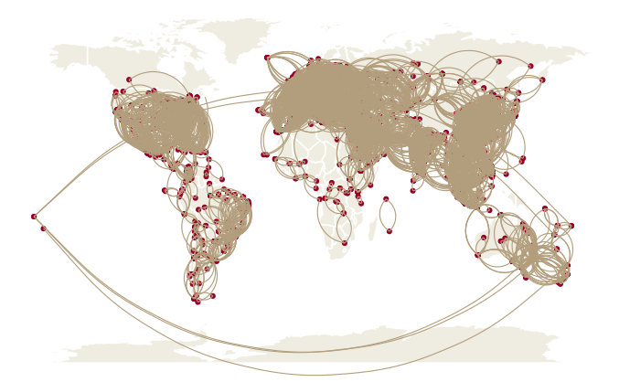

```r
worldmap <- borders("world", colour = "#FFFFFF", fill = "#efede1")
  ggplot() + worldmap +
    geom_point(data = routes_320_short, aes(x = source_longitude, y = source_latitude), col = "#970027") +
    geom_curve(data = routes_320_short, aes(x = source_longitude, y = source_latitude, xend = destination_longitude, yend = destination_latitude),
               col = "#b29e7d", size = .4) +
    theme_void()
```